# 9 Preparación de los datos

## Intentemos inspeccionar nuestros datos y entenderlos mejor

```python
movies.info()
```

```
<class 'pandas.core.frame.DataFrame'>
RangeIndex: 5043 entries, 0 to 5042
Data columns (total 19 columns):
movie_title                  5043 non-null object
title_year                   4935 non-null float64
color                        5024 non-null object
aspect_ratio                 4714 non-null float64
duration                     5028 non-null float64
language                     5031 non-null object
country                      5038 non-null object
duration.1                   5028 non-null float64
genres                       5043 non-null object
content_rating               4740 non-null object
plot_keywords                4890 non-null object
director_name                4939 non-null object
actor_1_name                 5036 non-null object
actor_2_name                 5030 non-null object
actor_3_name                 5020 non-null object
cast_total_facebook_likes    5043 non-null int64
budget                       4551 non-null float64
imdb_score                   5043 non-null float64
gross                        4159 non-null float64
dtypes: float64(7), int64(1), object(11)
memory usage: 748.6+ KB
```

A diferencia de Numpy, Pandas permite cargar no solo datos numericos pero tambien **datos de texto** que vemos por ejemplo en las columnas de actores y **mezclar distintos tipos de datos**.

- int64 y float64 corresponden a los mismos dtypes de Numpy
- object es el dtype que permite manejar datos de texto

```python
# columnas númericas y columnas de texto
movies.dtypes == float
```

```
movie_title                  False
title_year                    True
color                        False
aspect_ratio                  True
duration                      True
language                     False
country                      False
duration.1                    True
genres                       False
content_rating               False
plot_keywords                False
director_name                False
actor_1_name                 False
actor_2_name                 False
actor_3_name                 False
cast_total_facebook_likes    False
budget                        True
imdb_score                    True
gross                         True
dtype: bool
```

```python
movies.dtypes == int
```

```
movie_title                  False
title_year                   False
color                        False
aspect_ratio                 False
duration                     False
language                     False
country                      False
duration.1                   False
genres                       False
content_rating               False
plot_keywords                False
director_name                False
actor_1_name                 False
actor_2_name                 False
actor_3_name                 False
cast_total_facebook_likes     True
budget                       False
imdb_score                   False
gross                        False
dtype: bool
```

```python
movies.dtypes == object
```

```
movie_title                   True
title_year                   False
color                         True
aspect_ratio                 False
duration                     False
language                      True
country                       True
duration.1                   False
genres                        True
content_rating                True
plot_keywords                 True
director_name                 True
actor_1_name                  True
actor_2_name                  True
actor_3_name                  True
cast_total_facebook_likes    False
budget                       False
imdb_score                   False
gross                        False
dtype: bool
```

```python
num = (movies.dtypes == float) | (movies.dtypes == int)
num
```

```
movie_title                  False
title_year                    True
color                        False
aspect_ratio                  True
duration                      True
language                     False
country                      False
duration.1                    True
genres                       False
content_rating               False
plot_keywords                False
director_name                False
actor_1_name                 False
actor_2_name                 False
actor_3_name                 False
cast_total_facebook_likes     True
budget                        True
imdb_score                    True
gross                         True
dtype: bool
```

```python
num.index
```

```
Index(['movie_title', 'title_year', 'color', 'aspect_ratio', 'duration',
       'language', 'country', 'duration.1', 'genres', 'content_rating',
       'plot_keywords', 'director_name', 'actor_1_name', 'actor_2_name',
       'actor_3_name', 'cast_total_facebook_likes', 'budget', 'imdb_score',
       'gross'],
      dtype='object')
```

```python
for el in num.index:
    print(el)
```

```
movie_title
title_year
color
aspect_ratio
duration
language
country
duration.1
genres
content_rating
plot_keywords
director_name
actor_1_name
actor_2_name
actor_3_name
cast_total_facebook_likes
budget
imdb_score
gross
```

```python
num_cols = [c for c in num.index if num[c]]
```

```python
num_cols
```

```
['title_year',
 'aspect_ratio',
 'duration',
 'duration.1',
 'cast_total_facebook_likes',
 'budget',
 'imdb_score',
 'gross']
```

```python
movies.dtypes == object
```

```
movie_title                   True
title_year                   False
color                         True
aspect_ratio                 False
duration                     False
language                      True
country                       True
duration.1                   False
genres                        True
content_rating                True
plot_keywords                 True
director_name                 True
actor_1_name                  True
actor_2_name                  True
actor_3_name                  True
cast_total_facebook_likes    False
budget                       False
imdb_score                   False
gross                        False
dtype: bool
```

```python
obj = (movies.dtypes == object)
obj_cols = [c for c in obj.index if obj[c]]
```

```python
obj_cols
```

```
['movie_title',
 'color',
 'language',
 'country',
 'genres',
 'content_rating',
 'plot_keywords',
 'director_name',
 'actor_1_name',
 'actor_2_name',
 'actor_3_name']
```

```python
num_cols
```

```
['title_year',
 'aspect_ratio',
 'duration',
 'duration.1',
 'cast_total_facebook_likes',
 'budget',
 'imdb_score',
 'gross']
```

```python
movies_num = movies[num_cols]
```

```python
# Estadísticas de las columnas númericas
movies_num.describe()
```

|  | title_year | aspect_ratio | duration | duration.1 | cast_total_facebook_likes | budget | imdb_score | gross |
| --- | --- | --- | --- | --- | --- | --- | --- | --- |
| count | 4935.000000 | 4714.000000 | 5028.000000 | 5028.000000 | 5043.000000 | 4.551000e+03 | 5043.000000 | 4.159000e+03 |
| mean | 2002.470517 | 2.220403 | 107.201074 | 107.201074 | 9699.063851 | 3.975262e+07 | 6.442138 | 4.846841e+07 |
| std | 12.474599 | 1.385113 | 25.197441 | 25.197441 | 18163.799124 | 2.061149e+08 | 1.125116 | 6.845299e+07 |
| min | 1916.000000 | 1.180000 | 7.000000 | 7.000000 | 0.000000 | 2.180000e+02 | 1.600000 | 1.620000e+02 |
| 25% | 1999.000000 | 1.850000 | 93.000000 | 93.000000 | 1411.000000 | 6.000000e+06 | 5.800000 | 5.340988e+06 |
| 50% | 2005.000000 | 2.350000 | 103.000000 | 103.000000 | 3090.000000 | 2.000000e+07 | 6.600000 | 2.551750e+07 |
| 75% | 2011.000000 | 2.350000 | 118.000000 | 118.000000 | 13756.500000 | 4.500000e+07 | 7.200000 | 6.230944e+07 |
| max | 2016.000000 | 16.000000 | 511.000000 | 511.000000 | 656730.000000 | 1.221550e+10 | 9.500000 | 7.605058e+08 |

```python
# Estadísticas de las columnas de texto
```

Para hacer nuestro primer modelo más simple para este trabajaremos solo con las columnas númericas.

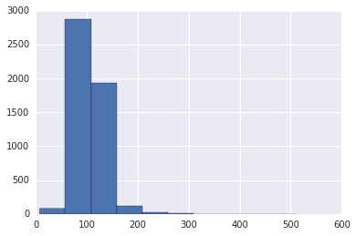

```python
movies_num['duration'].hist()
```

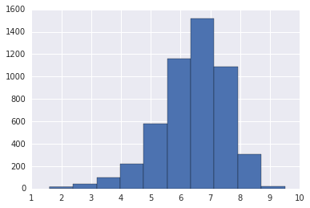

```python
movies_num['imdb_score'].hist()
```

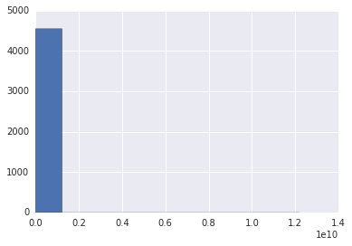

```python
movies_num['budget'].hist()
```

Para poder debuggear esta situación utilizaremos una tecnica muy tipica de pandas que se llama **boolean filtering**. Basicamente construimos una serie de booleanos con el mismo indice que nuestro dataframe (la serie clasicamente la llamaremos mask).

```python
mask = (movies_num['budget'] > 1e9)
```